# F1 Project

Hailey, Finn, Mia, Caeli

2025-11-18

```r
library(readxl)
library(tidyverse)
```

```r
library(ggplot2)
library(dplyr)

results <- read_excel("Results.xlsx")

results
```

```
## # A tibble: 439 × 19
##    DriverNumber BroadcastName Abbreviation TeamName TeamColor FirstName LastName
##           <dbl> <chr>         <chr>        <chr>    <chr>     <chr>     <chr>
##  1            1 M VERSTAPPEN  VER          Red Bul… 3671C6    Max       Verstap…
##  2           11 S PEREZ       PER          Red Bul… 3671C6    Sergio    Perez
##  3           14 F ALONSO      ALO          Aston M… 358C75    Fernando  Alonso
##  4           55 C SAINZ       SAI          Ferrari  F91536    Carlos    Sainz
##  5           44 L HAMILTON    HAM          Mercedes 6CD3BF    Lewis     Hamilton
##  6           18 L STROLL      STR          Aston M… 358C75    Lance     Stroll
##  7           63 G RUSSELL     RUS          Mercedes 6CD3BF    George    Russell
##  8           77 V BOTTAS      BOT          Alfa Ro… C92D4B    Valtteri  Bottas
##  9           10 P GASLY       GAS          Alpine   2293D1    Pierre    Gasly
## 10           23 A ALBON       ALB          Williams 37BEDD    Alexander Albon
## # ℹ 429 more rows
## # ℹ 12 more variables: FullName <chr>, Position <dbl>, GridPosition <dbl>,
## #   Q1 <lgl>, Q2 <lgl>, Q3 <lgl>, Time <chr>, Status <chr>, Points <dbl>,
## #   RoundNumber <dbl>, `Race Type` <chr>, EventName <chr>
```

```r
weather <- read_excel("Weather.xlsx")

weather
```

```
## # A tibble: 3,619 × 10
##    Time     AirTemp Humidity Pressure Rainfall TrackTemp WindDirection WindSpeed
##    <chr>      <dbl>    <dbl>    <dbl> <lgl>        <dbl>         <dbl>     <dbl>
##  1 0 days …    29.8       19    1016. FALSE         35.1           176       1.2
##  2 0 days …    29.7       19    1016. FALSE         35             182       1.2
##  3 0 days …    29.7       19    1016. FALSE         34.9           156       1.1
##  4 0 days …    29.6       19    1016. FALSE         34.9           201       0.8
##  5 0 days …    29.6       19    1016. FALSE         34.8           219       0.8
##  6 0 days …    29.6       19    1016. FALSE         34.7           219       0.8
##  7 0 days …    29.6       19    1016. FALSE         34.7           196       0.6
##  8 0 days …    29.6       18    1016. FALSE         34.6           200       0.6
##  9 0 days …    29.5       18    1016. FALSE         34.5           180       0.8
## 10 0 days …    29.5       18    1016. FALSE         34.4           184       1.2
## # ℹ 3,609 more rows
## # ℹ 2 more variables: RoundNumber <dbl>, EventName <chr>
```

```r
results <- results %>%
  select(TeamName, FullName, Position, GridPosition, Status, Points, RoundNumber, EventName) %>%
  mutate(
    Position = as.integer(Position),
    GridPosition = as.integer(GridPosition),
    Points = as.integer(Points),
    RoundNumber = as.integer(RoundNumber)
  ) %>%
  rename (
    DriverName = FullName,
    Result = Position,
    QualiPosition = GridPosition
  )


results
```

```
## # A tibble: 439 × 8
##    TeamName  DriverName Result QualiPosition Status Points RoundNumber EventName
##    <chr>     <chr>       <int>         <int> <chr>   <int>       <int> <chr>
##  1 Red Bull… Max Verst…      1             1 Finis…     25           1 Bahrain …
##  2 Red Bull… Sergio Pe…      2             2 Finis…     18           1 Bahrain …
##  3 Aston Ma… Fernando …      3             5 Finis…     15           1 Bahrain …
##  4 Ferrari   Carlos Sa…      4             4 Finis…     12           1 Bahrain …
##  5 Mercedes  Lewis Ham…      5             7 Finis…     10           1 Bahrain …
##  6 Aston Ma… Lance Str…      6             8 Finis…      8           1 Bahrain …
##  7 Mercedes  George Ru…      7             6 Finis…      6           1 Bahrain …
##  8 Alfa Rom… Valtteri …      8            12 Finis…      4           1 Bahrain …
##  9 Alpine    Pierre Ga…      9            20 Finis…      2           1 Bahrain …
## 10 Williams  Alexander…     10            15 Finis…      1           1 Bahrain …
## # ℹ 429 more rows
```

```r
weather <- weather %>%
  select(Rainfall, TrackTemp, RoundNumber, EventName) %>%
  mutate(RoundNumber = as.integer(RoundNumber)) %>%
  rename(Rain = Rainfall)

weather
```

```
## # A tibble: 3,619 × 4
##    Rain  TrackTemp RoundNumber EventName
##    <lgl>     <dbl>       <int> <chr>
##  1 FALSE      35.1           1 Bahrain Grand Prix
##  2 FALSE      35             1 Bahrain Grand Prix
##  3 FALSE      34.9           1 Bahrain Grand Prix
##  4 FALSE      34.9           1 Bahrain Grand Prix
##  5 FALSE      34.8           1 Bahrain Grand Prix
##  6 FALSE      34.7           1 Bahrain Grand Prix
##  7 FALSE      34.7           1 Bahrain Grand Prix
##  8 FALSE      34.6           1 Bahrain Grand Prix
##  9 FALSE      34.5           1 Bahrain Grand Prix
## 10 FALSE      34.4           1 Bahrain Grand Prix
## # ℹ 3,609 more rows
```

**The below section breaks the weather dataframe into 2 parts: track temperature and rainy races. The average track temperature for each race & round number is found. The number of races that had more than 10 true’s under rain was also found.**

```r
track_only <- weather %>%
  group_by(EventName, RoundNumber) %>%
  summarize(AvgTrackTemp = mean(TrackTemp, na.rm=T)) %>%
  arrange(desc(AvgTrackTemp))
track_only
```

```
## # A tibble: 22 × 3
## # Groups:   EventName [22]
##    EventName                RoundNumber AvgTrackTemp
##    <chr>                          <int>        <dbl>
##  1 Hungarian Grand Prix              11         48.6
##  2 SÃ£o Paulo Grand Prix             20         46.8
##  3 Mexico City Grand Prix            19         45.6
##  4 Italian Grand Prix                14         42.9
##  5 Japanese Grand Prix               16         42.1
##  6 Azerbaijan Grand Prix              4         41.2
##  7 United States Grand Prix          18         40.6
##  8 Monaco Grand Prix                  6         39.3
##  9 Qatar Grand Prix                  17         36.9
## 10 Miami Grand Prix                   5         36.7
## # ℹ 12 more rows
```

```r
rain_only <- weather %>%
  group_by(EventName, RoundNumber) %>%
  summarize(NumRain = sum(Rain)) %>%
  filter(NumRain >= 10)
rain_only
```

```
## # A tibble: 3 × 3
## # Groups:   EventName [3]
##   EventName          RoundNumber NumRain
##   <chr>                    <int>   <int>
## 1 Belgian Grand Prix          12      11
## 2 Dutch Grand Prix            13      48
## 3 Monaco Grand Prix            6      26
```

**This is a bar graph of the average points scored per race for each driver during the ’23 season. The bars are colored based on the team the driver drives for. It reveals that Max Verstappen has the highest average number of points scored each race and Sergio Perez had the second highest number of points scored each race. Both drivers race for Red Bull Racing. The plot reveals Verstappen and then Perez are the most consistent drivers and Red Bull Racing is the most consistent constructor. The least consistent drivers were Nyck De Vries (least reliable) and then Logan Sargeont. The least reliable constructors appear to be AlphaTauri, Haas, and Alfa Romeo.**

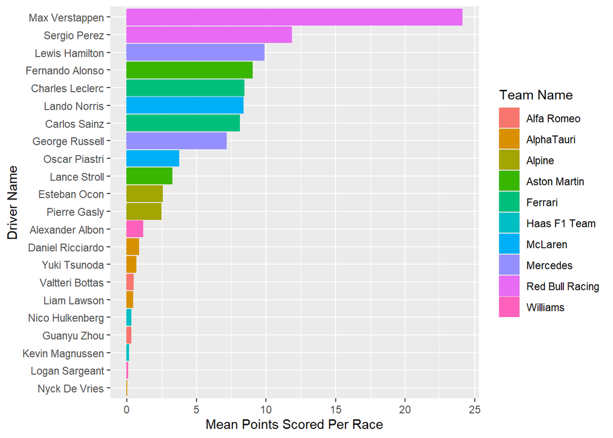

```r
results %>%
  group_by(DriverName, TeamName) %>%
  summarize(mean_pts_scored = mean(Points, na.rm = T), .groups = "drop") %>%
  ggplot(aes(x = reorder(DriverName, mean_pts_scored), y = mean_pts_scored))+
  geom_bar(stat = "identity", aes(color = TeamName, fill = TeamName))+
  coord_flip() +
  labs(y = "Mean Points Scored Per Race", x = "Driver Name", color = "Team Name", fill = "Team Name")
```

**Scatterplot of average track temp vs. total points scored by constructor.**

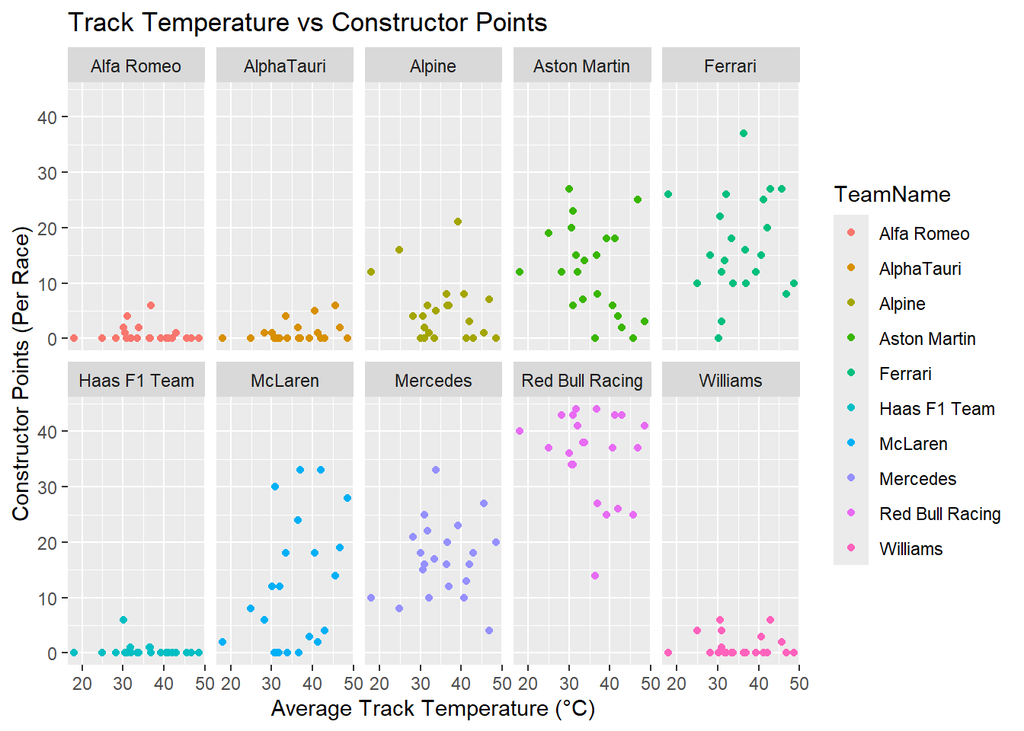

```r
results %>%
  group_by(TeamName, EventName, RoundNumber) %>%
  summarize(race_points = sum(Points), .groups = "drop") %>%
  arrange(desc(race_points)) -> team_pts_by_race

team_track <- team_pts_by_race %>%
  left_join(track_only, by = c("EventName", "RoundNumber"))

ggplot(data = team_track, aes(x = AvgTrackTemp, y = race_points, color = TeamName)) +
  geom_point() +
  labs(
    x = "Average Track Temperature (°C)",
    y = "Constructor Points (Per Race)",
    title = "Track Temperature vs Constructor Points"
  ) +
  facet_wrap(~TeamName, ncol = 5)
```

**Red Bull consistent (but with some outliers in higher temp)** **Mercedes, Ferrari all over the place- car upgrades after a bad race** **Hass, Alfa Romeo, Williams consistently bad (slightly better in the middle)** **Alpha Tauri, Mclaren better in higher temp** **Aston Martin more consistent in colder temps, scattered in higher temps** **Alpine did well in colder temps, consistent in higher temps (except for outlier)**

```r
results %>%
  group_by(TeamName, EventName, RoundNumber, DriverName) %>%
  summarize(race_points = sum(Points), .groups = "drop") %>%
  arrange(desc(race_points)) -> pts_by_race

individual_track <- pts_by_race %>%
  left_join(track_only, by = c("EventName", "RoundNumber"))

individual_track
```

```
## # A tibble: 439 × 6
##    TeamName        EventName     RoundNumber DriverName race_points AvgTrackTemp
##    <chr>           <chr>               <int> <chr>            <int>        <dbl>
##  1 Red Bull Racing Abu Dhabi Gr…          22 Max Verst…          26         33.5
##  2 Red Bull Racing Austrian Gra…           9 Max Verst…          26         32.1
##  3 Red Bull Racing British Gran…          10 Max Verst…          26         30.9
##  4 Red Bull Racing Hungarian Gr…          11 Max Verst…          26         48.6
##  5 Red Bull Racing Japanese Gra…          16 Max Verst…          26         42.1
##  6 Red Bull Racing Miami Grand …           5 Max Verst…          26         36.7
##  7 Red Bull Racing Qatar Grand …          17 Max Verst…          26         36.9
##  8 Red Bull Racing Spanish Gran…           7 Max Verst…          26         33.8
##  9 Ferrari         Singapore Gr…          15 Carlos Sa…          25         36.4
## 10 Red Bull Racing Australian G…           3 Max Verst…          25         30.1
## # ℹ 429 more rows
```

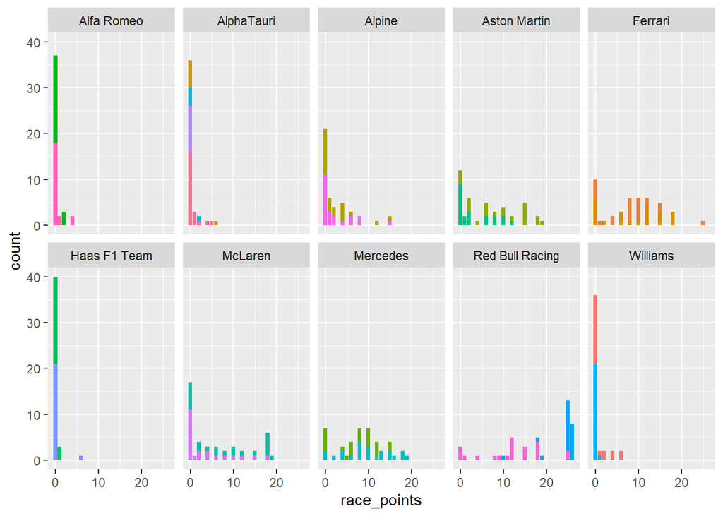

```r
ggplot(data = individual_track, aes(x=race_points, fill=DriverName)) +
  geom_bar() +
  facet_wrap(~TeamName, ncol=5) +
  theme(legend.position = "none")
```

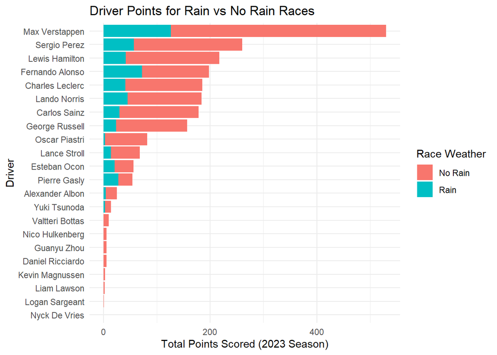

```r
results_rain <- results %>%
  left_join(
    weather %>%
      group_by(EventName, RoundNumber) %>%
      summarize(
        NumRainRaces = sum(Rain, na.rm = T),
        RaceWeather = if_else(NumRainRaces > 0, "Rain", "No Rain"),
        .groups = "drop"
      ) %>%
      mutate(
        RaceWeather = factor(RaceWeather, levels = c("No Rain", "Rain"))
      ),
    by = c("EventName", "RoundNumber")
  ) %>%
  group_by(DriverName, RaceWeather) %>%
  summarize(TotalPts = sum(Points, na.rm = T), .groups = "drop_last") %>%
  mutate(DriverTotalPts = sum(TotalPts, na.rm = T)) %>%
  ungroup() %>%
  ggplot(aes(
         x = reorder(DriverName, DriverTotalPts),
         y = TotalPts,
         fill = RaceWeather
       )) +
  geom_bar(stat = "identity") +
  coord_flip() +
  labs(
    x = "Driver",
    y = "Total Points Scored (2023 Season)",
    fill = "Race Weather",
    title = "Driver Points for Rain vs No Rain Races"
  ) +
  theme_minimal()

results_rain
```